# Analysis of Indicator

Matt Dzaugis

2022-01-19

```r
# Indicators
allIndicators <- read_csv(here::here("Processed_Indicators/allIndicators.csv"))
allIndicators$Season <- factor(allIndicators$Season, levels= c("spring", "summer", "fall", "winter", "all"))
allIndicators$stat_area <- factor(allIndicators$stat_area, levels= c("511", "512", "513", "511-513"))
indicator <- data.frame("name" = unique(allIndicators$Indicator))
indicator <- indicator %>%
  mutate(long_name = case_when(name == "fvcom_bt"~"FVCOM NECOFS bottom temperature",
                      name == "fvcom_sst"~"FVCOM NECOFS surface temperature",
                      name == "oisst"~"OISSTv2.1",
                      name == "fvcom_bs"~"FVCOM NECOFS bottom salinity",
                      name == "fvcom_sss"~"FVCOM NECOFS surface salinity",
                      name == "mcc"~"Maine Coastal Current Index",
                      name == "stratification"~"Stratification Index",
                      name == "nefsc_biomass"~"NEFSC lobster predator biomass",
                      name == "nefsc_abundance"~"NEFSC lobster predator abundance",
                      name == "menh_abundance"~"ME/NH inshore trawl lobster predator abundance",
                      name == "menh_biomass"~"ME/NH inshore trawl lobster predator biomass",
                      name == "nefsc_size_spectra_slope"~"NEFSC size-based predator index",
                      name == "menh_size_spectra_slope"~"ME/NH size-based predator index",
                      name == "cpr_FirstMode"~"Small zooplankton index",
                      name == "cpr_SecondMode"~"Calanus index"))
# Enter indicator, season, stat area of interest

indicator_sel <- params$indicator
season_sel <- params$season
stat_areas_sel <- params$stat_area
long_name <- indicator$long_name[indicator$name == indicator_sel]

df1 <- allIndicators %>%
  filter(Indicator == indicator_sel)

seasons <- unique(df1$Season)
stat_areas <- unique(df1$stat_area)

if(season_sel %not in% seasons){
  season_sel <- "all"
  note1 <- "Selected season not available for this indicator. Returned result with 'all' seasons."
} else {
  note1 <- season_sel
}

if(stat_areas_sel %not in% stat_areas){
  stat_areas_sel <- "511-513"
  note2 <- "Selected stat area not available for this indicator. Returned result with stat areas '511-513'."
} else {
  note2 <- stat_areas_sel
}

df <- allIndicators %>%
    filter(Indicator == indicator_sel,
           Season == season_sel,
           stat_area == stat_areas_sel) %>%
    na.omit()
```

```r
plot_fun <- function(x){
  x %>%
    ggplot() +
    geom_line(aes(Year, Value, col = stat_area)) +
    theme_bw() +
    facet_wrap(~Season)
}

sumLms_fun <- function(x){
  lm1 <- lm(Value ~ Year, data = x)
  return(lm1)
}


acf_plot <- function(x){
    df <- x %>%
      select(Year, Value) %>%
    na.omit()
  acf(df)
}

pscore_fun <- function(x, nbreak){
  df <- x

  lm1 <- lm(Value ~ Year, data = df)
  pscore <- segmented::pscore.test(lm1, n.break = nbreak)
  return(pscore)
}

davies_fun <- function(x){
  df <- x

  lm1 <- lm(Value ~ Year, data = df)
  davies <- segmented::davies.test(lm1)
  return(davies)
}

slope_bp_fun <- function(x, Npsi){
    df <- x

  lm1 <- lm(Value ~ Year, data = df)

  segmented::segmented(lm1, seg.Z = ~Year, npsi = Npsi)

}

mean_bp_fun <- function(x, models){
    df <- x

  lm1 <- lm(Value ~ Year, data = df)
  temp_mcp1 <- mcp::mcp(models, data = df, par_x = "Year")
  return(temp_mcp1)
}
```

## Developing Indicators of Habitat and Ecosystem Change in the Gulf of Maine

This report includes the initial analysis of the ecosystem and habitat indicators. Linear regression was used to assess trends over the length of the time series. A trend breakpoint analysis and a mean breakpoint analysis were run on the indicators. A breakpoint found in the slope of the line indicates a change in the trend of the data. A breakpoint in the mean of the date may indicate a regime shift or change of the overall state of the system. These analyses were run seasonally within statistical areas, when available, and as yearly averages across the entire study domain.

## Indicators

The following indicators are used in this report

- Maine Coastal Current Index

The following season and stat area are used in this report

- all
- 511-513

### Maine Coastal Current Index

#### Time series plot

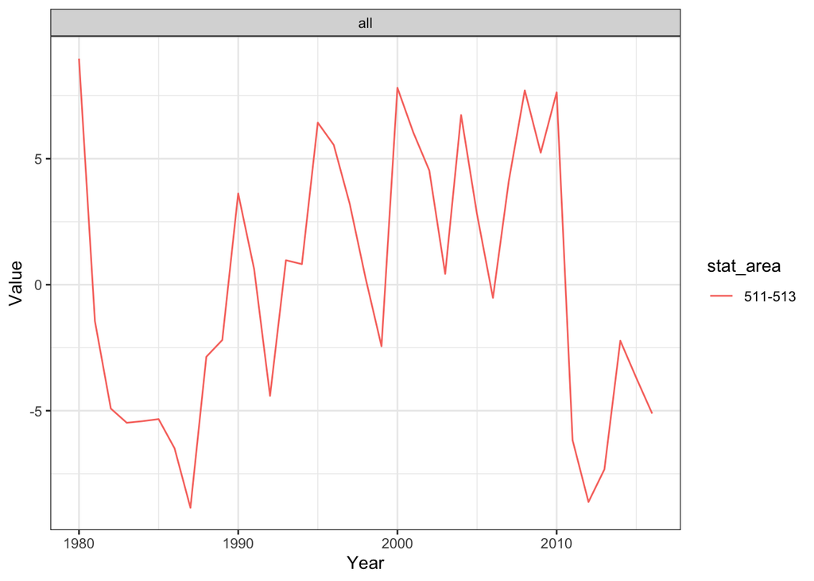

```r
plot_fun(df)
```

#### Linear models

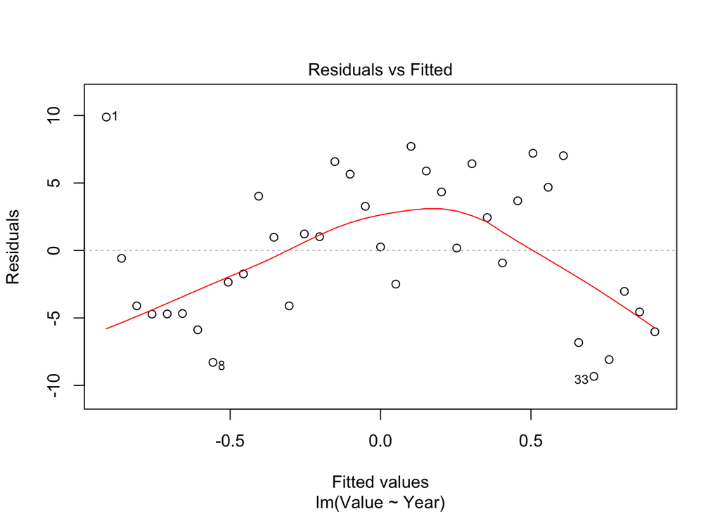

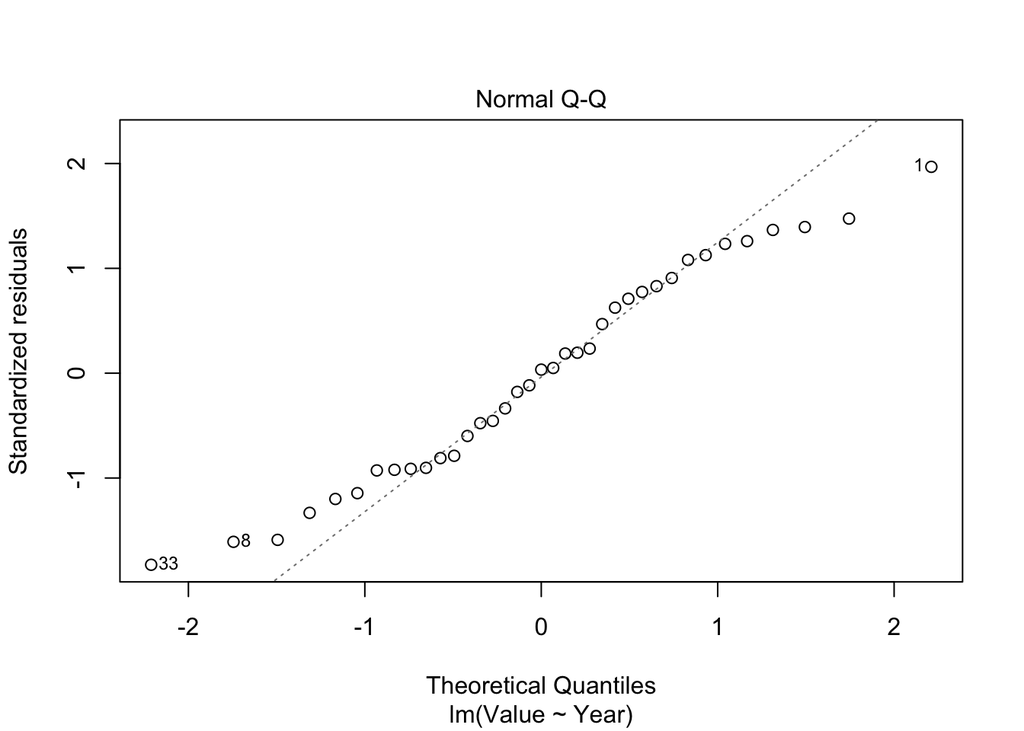

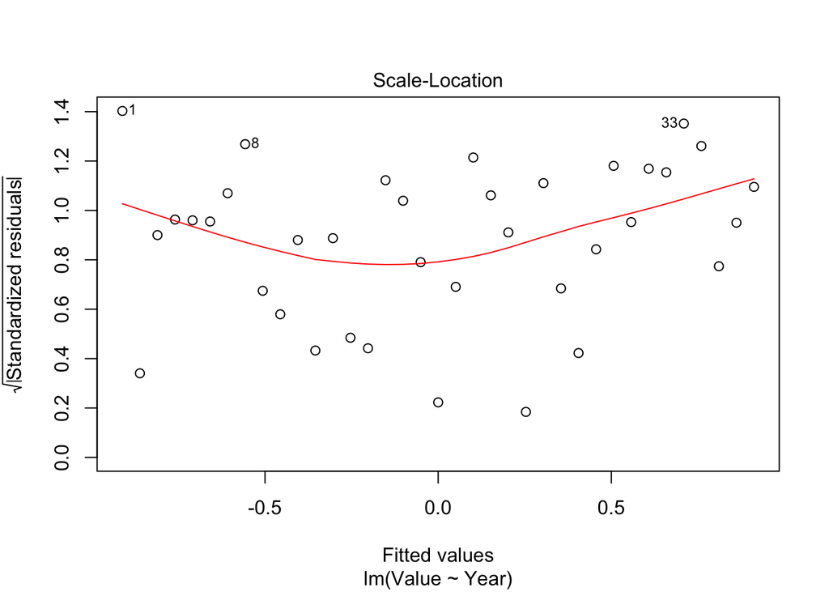

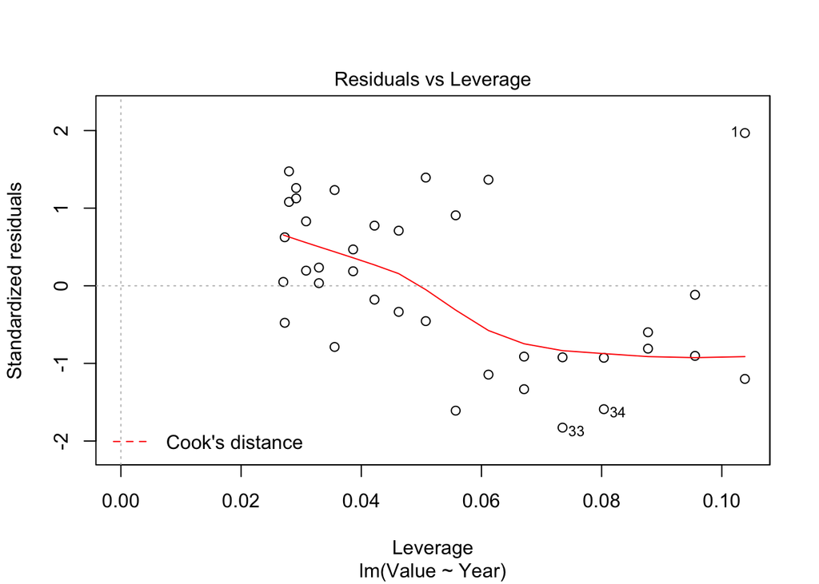

```r
lms <- sumLms_fun(df)
plot(lms)
```

```r
summary(lms)
```

```
##
## Call:
## lm(formula = Value ~ Year, data = x)
##
## Residuals:
##     Min      1Q  Median      3Q     Max
## -9.3314 -4.5559  0.1769  4.3347  9.8842
##
## Coefficients:
##               Estimate Std. Error t value Pr(>|t|)
## (Intercept) -101.20142  163.19817   -0.62    0.539
## Year           0.05065    0.08168    0.62    0.539
##
## Residual standard error: 5.305 on 35 degrees of freedom
## Multiple R-squared:  0.01087,    Adjusted R-squared:  -0.01739
## F-statistic: 0.3846 on 1 and 35 DF,  p-value: 0.5392
```

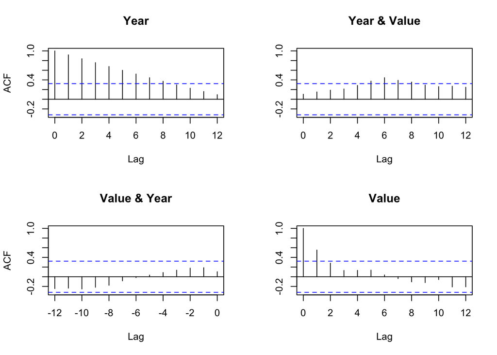

```r
acf_plot(df)
```

#### Slope breakpoint tests

The pscore test and davies tests indicate whether a breakpoint in the slope exists. The davies test is more sensitive to data that follow a more sinusoidal curve but less sensitive to linear changes. A significant p-value indicates there is a breakpoint in the data. A non-significant p-value indicates a breakpoint is not present.

```r
pscore_fun(df, 1)
```

```
##
##  Score test for one/two changes in the slope
##
## data:  formula = Value ~ Year
## breakpoint for variable = Year
## model = gaussian , link = identity , method = lm
## observed value = -2.6092, n.points = 10, p-value = 0.01326
## alternative hypothesis: two.sided   (1 breakpoint)
```

```r
pscore_fun(df, 2)
```

```
##
##  Score test for one/two changes in the slope
##
## data:  formula = Value ~ Year
## breakpoint for variable = Year
## model = gaussian , link = identity , method = lm
## observed value = 13.921, n.points = 10, p-value = 0.0009487
## alternative hypothesis: two.sided   (2 breakpoints)
```

```r
davies_fun(df)
```

```
##
##  Davies' test for a change in the slope
##
## data:  formula = Value ~ Year ,   method = lm
## model = gaussian , link = identity
## segmented variable = Year
## 'best' at = 2007.4, n.points = 10, p-value = 0.002965
## alternative hypothesis: two.sided
```

#### Slope breakpoint (1)

```r
# Enter the npsi (estimated number of breakpoints) - might need to run the code first and assess the breakpoint stats
bp <- slope_bp_fun(df, 1)
summary(bp)
```

```
##
##  ***Regression Model with Segmented Relationship(s)***
##
## Call:
## segmented.lm(obj = lm1, seg.Z = ~Year, npsi = Npsi)
##
## Estimated Break-Point(s):
##            Est. St.Err
## psi1.Year 2008  1.694
##
## Meaningful coefficients of the linear terms:
##              Estimate Std. Error t value Pr(>|t|)
## (Intercept) -607.1315   206.5044  -2.940  0.00595 **
## Year           0.3048     0.1036   2.942  0.00592 **
## U1.Year       -1.9006     0.5809  -3.272       NA
## ---
## Signif. codes:  0 '***' 0.001 '**' 0.01 '*' 0.05 '.' 0.1 ' ' 1
##
## Residual standard error: 4.428 on 33 degrees of freedom
## Multiple R-Squared: 0.3503,  Adjusted R-squared: 0.2912
##
## Convergence attained in 5 iter. (rel. change 9.514e-06)
```

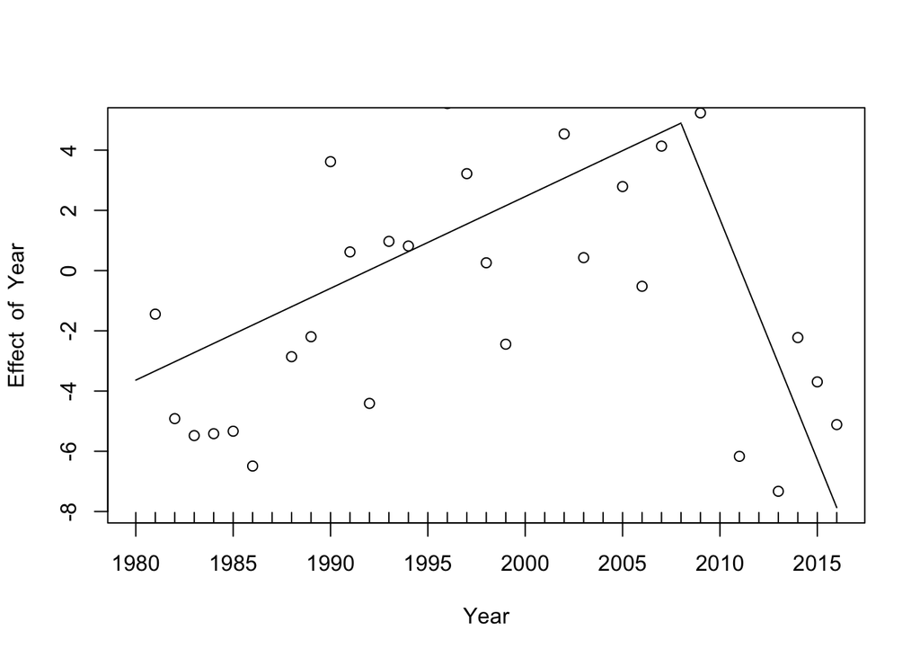

```r
plot(bp)
points(x = df$Year, y = df$Value)
```

#### Slope breakpoint (2)

```r
# Enter the npsi (estimated number of breakpoints) - might need to run the code first and assess the breakpoint stats
bp <- slope_bp_fun(df, 2)
summary(bp)
```

```
##
##  ***Regression Model with Segmented Relationship(s)***
##
## Call:
## segmented.lm(obj = lm1, seg.Z = ~Year, npsi = Npsi)
##
## Estimated Break-Point(s):
##                Est. St.Err
## psi1.Year 1981.485  0.559
## psi2.Year 2004.017  1.646
##
## Meaningful coefficients of the linear terms:
##               Estimate Std. Error t value Pr(>|t|)
## (Intercept) 20639.8456 10617.9048   1.944   0.0610 .
## Year          -10.4196     5.3612  -1.944   0.0611 .
## U1.Year        10.9785     5.3627   2.047       NA
## U2.Year        -1.5775     0.3087  -5.110       NA
## ---
## Signif. codes:  0 '***' 0.001 '**' 0.01 '*' 0.05 '.' 0.1 ' ' 1
##
## Residual standard error: 3.791 on 31 degrees of freedom
## Multiple R-Squared: 0.5526,  Adjusted R-squared: 0.4804
##
## Convergence attained in 3 iter. (rel. change 9.8616e-06)
```

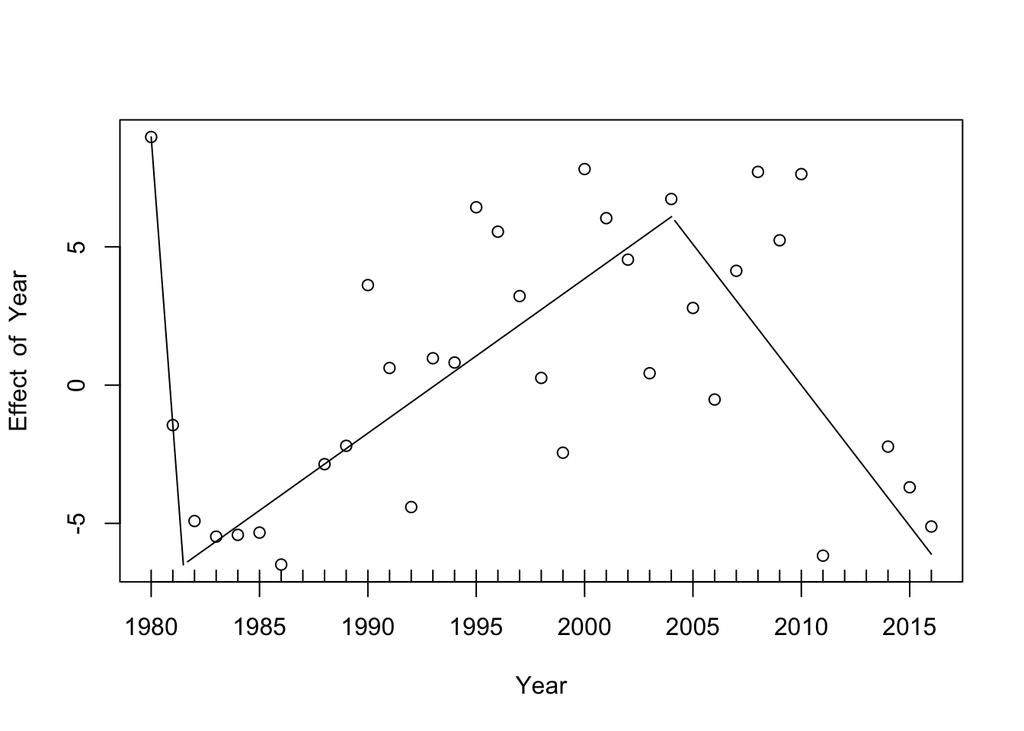

```r
plot(bp)
points(x = df$Year, y = df$Value)
```

#### Slope breakpoint (3)

```r
# Enter the npsi (estimated number of breakpoints) - might need to run the code first and assess the breakpoint stats
bp <- slope_bp_fun(df, 3)
summary(bp)
```

```
##
## Call:
## lm(formula = Value ~ Year, data = df)
##
## Residuals:
##     Min      1Q  Median      3Q     Max
## -9.3314 -4.5559  0.1769  4.3347  9.8842
##
## Coefficients:
##               Estimate Std. Error t value Pr(>|t|)
## (Intercept) -101.20142  163.19817   -0.62    0.539
## Year           0.05065    0.08168    0.62    0.539
##
## Residual standard error: 5.305 on 35 degrees of freedom
## Multiple R-squared:  0.01087,    Adjusted R-squared:  -0.01739
## F-statistic: 0.3846 on 1 and 35 DF,  p-value: 0.5392
```

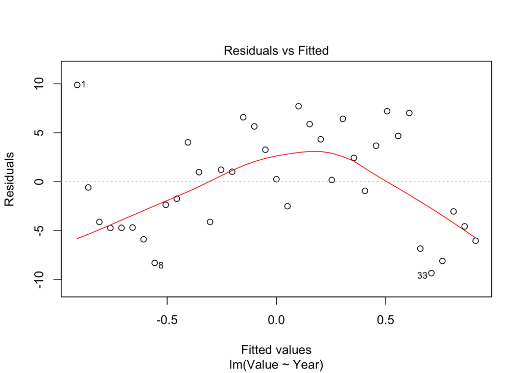

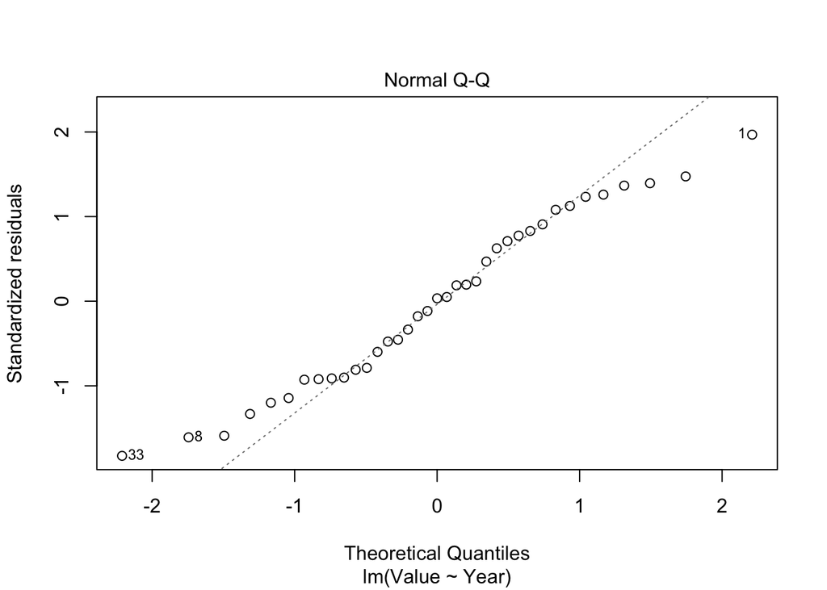

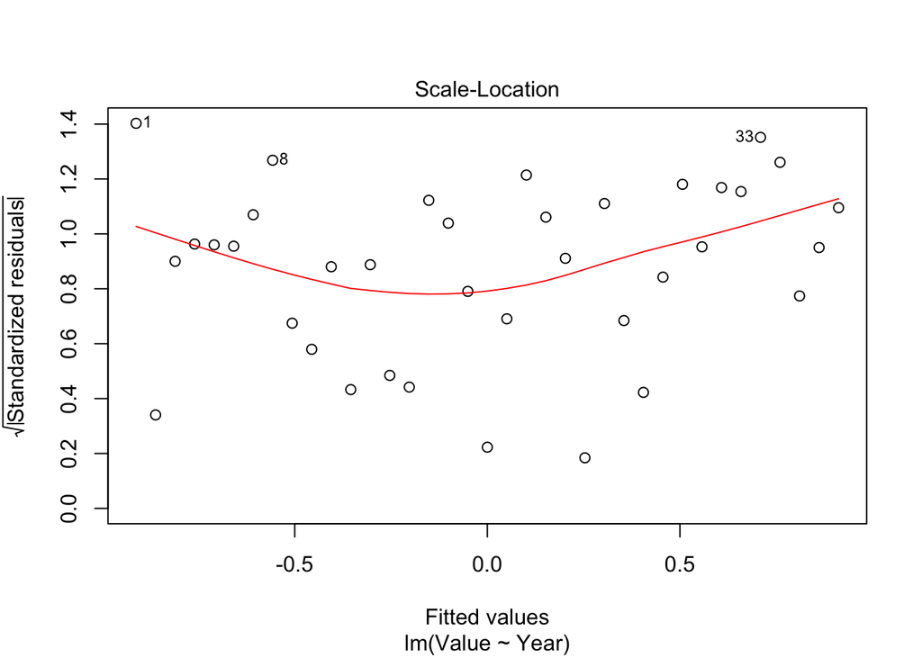

```r
plot(bp)
```

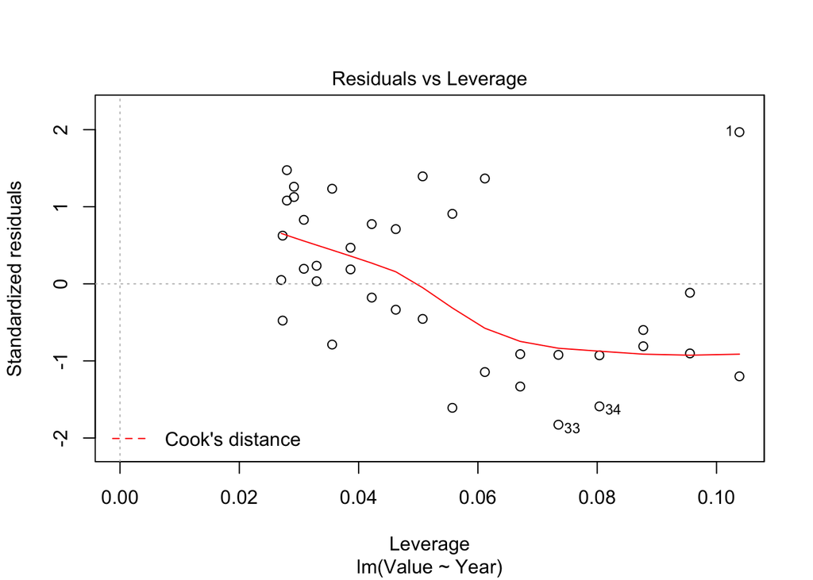

```r
points(x = df$Year, y = df$Value)
```

#### Mean breakpoint (1)

```r
# enter a list of models for the mean breakpoint - a model of 1~1 indicates intercept, adding additional models incudes additional bp
model_list <- list(Value~1, 1~1)
mean_cp <- mean_bp_fun(df, model_list)
summary(mean_cp)
```

```
## Family: gaussian(link = 'identity')
## Iterations: 9000 from 3 chains.
## Segments:
##   1: Value ~ 1
##   2: Value ~ 1 ~ 1
##
## Population-level parameters:
##     name    mean  lower  upper Rhat n.eff
##     cp_1 1999.56 1980.0 2012.2    1    50
##    int_1   -0.54   -6.6    3.4    1   225
##    int_2   -1.74   -8.2    3.1    1    87
##  sigma_1    5.04    3.9    6.3    1  3354
```

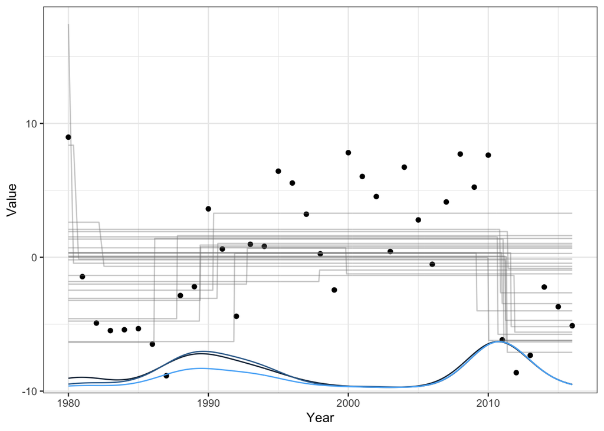

```r
plot(mean_cp)
```

#### Mean breakpoint (2)

```r
# enter a list of models for the mean breakpoint - a model of 1~1 indicates intercept, adding additional models incudes additional bp
model_list <- list(Value~1, 1~1, 1~1)
mean_cp <- mean_bp_fun(df, model_list)
summary(mean_cp)
```

```
## Family: gaussian(link = 'identity')
## Iterations: 9000 from 3 chains.
## Segments:
##   1: Value ~ 1
##   2: Value ~ 1 ~ 1
##   3: Value ~ 1 ~ 1
##
## Population-level parameters:
##     name   mean  lower   upper Rhat n.eff
##     cp_1 1992.4 1987.0 1995.54    1   581
##     cp_2 2010.5 2010.0 2011.51    1  2121
##    int_1   -2.6   -5.1   -0.24    1  2258
##    int_2    3.6    1.7    5.74    1  2044
##    int_3   -5.3   -8.7   -2.23    1  3517
##  sigma_1    3.9    3.0    4.98    1  3042
```

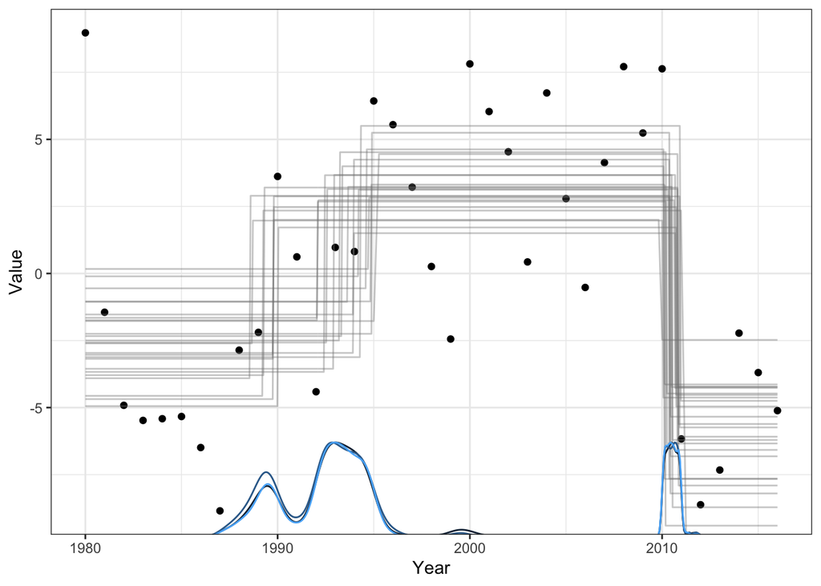

```r
plot(mean_cp)
```